# An investigation of the relationship between speed limit and various demographic, environmental and spatial factors on road accident severity in Great Britain

Group 9

27/02/2023

## Introduction

According to the World Health Organisation, there are approximately 1.3 million fatalities globally each year due to road traffic accidents (1). Indeed, road traffic injuries are the primary cause of death for those aged between five and 29 years old (1). Although most deaths occur in low- to middle-income countries, it is nevertheless an issue of significant concern for high-income countries also.  
It is well known that driving at an increased speed is related to both the risk of a road traffic accident and the severity of the accident, should it occur (1). However, there are a number of other factors that influence accident severity and these include factors such as drunk driving, speeding, younger drivers, proximity of vehicles and pedestrians, road conditions and the interaction between these factors.

An increased understanding of the impact of these factors on road accident severity could aid policymakers in decision making and be used to implement targeted preventative measures enabling optimal use of finite resources and increasing road safety for all users.

It is difficult to identify and capture all factors that influence the severity of accidents. In Great Britain, the Department of Transport systematically collects and publishes data relating to accidents, the vehicles and casualties involved in those accidents. This dataset provides an opportunity to assess key factors associated with severity of accidents. The primary aim of this analysis is to determine the relationship between speed limits and the severity of road traffic accidents, adjusting for all other relevant factors. Secondary aims include investigating the effects of environmental, demographic and other factors on road accident severity. More specifically, the relationship between accident severity and road surface conditions, time of day, casualty type, maximum age of vehicles involved, and whether the drivers were under 25 years old, will be explored as secondary aims.

Information on the data source and methods used to analyse the data will be provided in the subsequent Methods section. The Results section will present the main findings, including figures and tables. The Conclusions and Discussion section will elaborate on the findings and discuss the limitations of the analysis.

## Methods

### Data Sources

This retrospective analysis utilised road safety data for the year 2020, available online from the UK’s Department of Transport website (2). The dataset included details of road accidents that occurred on public roads in Great Britain, involving at least one vehicle and resulting in human injury. Information is available on the circumstances of the accident, such as weather conditions, time of day, visibility, speed limit, road type and surface conditions. In addition, data was available on the types of vehicles and characteristics of the casualties involved in these accidents which can be linked through a common accident reference number. We downloaded data on all accidents and the associated casualties and vehicles to create a single dataset. Each accident was indicated by a unique reference number, which was also included in the vehicles and casualties dataset. Using the common accident reference number, the three datasets were linked. As a single accident could be associated with multiple casualties and vehicles, we used various conditions to identify and summarise key factors for each accident. The final dataset contains complete information on the vehicles and accidents in one row for each accident.

### Selection of variables

The outcome variable for this analysis was accident severity. The available data reports accident severity as fatal, serious or slight. For this analysis, the fatal and serious groups were combined, so that accidents were divided into two categories: ‘fatal or serious’ and ‘slight.’

In addition, a subset of the other available variables were extracted from the datasets, based on their potential to impact accident severity. These factors include the following:

After data cleaning and checks, we conducted exploratory data analysis and produced 2x2 tables and plots to describe the data. Speed limit and maximum age of the vehicle were kept as continuous variables. All other variables were included as nominal variables. A statistical method called logistic regression was used to assess the influence of different factors on the risk of severe accidents. This method was chosen because it allows the assessment of the relationship between a binary outcome (severe accident or not) and potential factors that may increase or decrease the risk of the outcome. After checking that the model was appropriate for interpretation, we calculated the predicted probability of an accident being severeoutcome for the various factors.

## Results

In 2020, there were 91199 recorded accidents, involving 167374 vehicles and resulting in 115584 casualties. Among the recorded accidents, 21.6% (19,746) were classified as being severe.

Among accidents, the highest number of slight and severe outcomes were recorded in roads with a 30 miles per hour (mph) speed limit (Figure 1). However, the proportion of severe accidents increased with increasing speed limit, with the highest proportion recorded at 60mph.

[figure not shown]

| Variable | levels | Slight | Severe | Total |
| --- | --- | --- | --- | --- |
| Speed limit | Median (IQR) | 30.0 (30.0 to 40.0) | 30.0 (30.0 to 50.0) | 30.0 (30.0 to 40.0) |
| Road surface conditions | Dry | 49095 (78.3) | 13603 (21.7) | 62698 |
|  | Other | 851 (77.5) | 247 (22.5) | 1098 |
|  | Wet or damp | 20459 (78.0) | 5781 (22.0) | 26240 |
|  | (Missing) | 1048 (90.1) | 115 (9.9) | 1163 |
| Urban or rural area | Urban | 50188 (81.3) | 11549 (18.7) | 61737 |
|  | Rural | 21253 (72.2) | 8195 (27.8) | 29448 |
|  | (Missing) | 12 (85.7) | 2 (14.3) | 14 |
| Trunk road | Trunk | 4147 (78.7) | 1120 (21.3) | 5267 |
|  | Non-trunk | 62805 (79.3) | 16417 (20.7) | 79222 |
|  | (Missing) | 4501 (67.1) | 2209 (32.9) | 6710 |
| Time of day | 7-10am | 10486 (81.2) | 2434 (18.8) | 12920 |
|  | 10am-4pm | 26608 (78.9) | 7119 (21.1) | 33727 |
|  | 4-7pm | 17148 (78.6) | 4664 (21.4) | 21812 |
|  | 7-11pm | 11177 (77.5) | 3247 (22.5) | 14424 |
|  | 11pm-7am | 6034 (72.6) | 2282 (27.4) | 8316 |
| Vehicle max age | Median (IQR) | 10.0 (5.0 to 14.0) | 10.0 (5.0 to 14.0) | 10.0 (5.0 to 14.0) |
| Vehicle car | No | 8040 (66.1) | 4130 (33.9) | 12170 |
|  | Yes | 63413 (80.2) | 15616 (19.8) | 79029 |
| Vehicle heavy | No | 59748 (78.2) | 16609 (21.8) | 76357 |
|  | Yes | 11705 (78.9) | 3137 (21.1) | 14842 |
| Vehicle other | No | 69011 (78.6) | 18818 (21.4) | 87829 |
|  | Yes | 2442 (72.5) | 928 (27.5) | 3370 |
| Vehicle motorcycle | No | 62021 (80.2) | 15345 (19.8) | 77366 |
|  | Yes | 9432 (68.2) | 4401 (31.8) | 13833 |
| Vehicle pedal cycle | No | 59079 (79.0) | 15665 (21.0) | 74744 |
|  | Yes | 12374 (75.2) | 4081 (24.8) | 16455 |
| Vehicle female driver | No | 39007 (73.9) | 13790 (26.1) | 52797 |
|  | Yes | 24175 (83.5) | 4761 (16.5) | 28936 |
|  | (Missing) | 8271 (87.4) | 1195 (12.6) | 9466 |
| Vehicle driver age under 25 | No | 52134 (77.8) | 14881 (22.2) | 67015 |
|  | Yes | 16421 (79.2) | 4325 (20.8) | 20746 |
|  | (Missing) | 2898 (84.3) | 540 (15.7) | 3438 |
| Casualty cyclist | No | 59337 (79.0) | 15758 (21.0) | 75095 |
|  | Yes | 12116 (75.2) | 3988 (24.8) | 16104 |
| Casualty car occupant | No | 33891 (72.5) | 12829 (27.5) | 46720 |
|  | Yes | 37562 (84.4) | 6917 (15.6) | 44479 |
| Casualty motorcycle | No | 62762 (80.1) | 15545 (19.9) | 78307 |
|  | Yes | 8691 (67.4) | 4201 (32.6) | 12892 |
| Casualty pedestrian | No | 61472 (79.8) | 15534 (20.2) | 77006 |
|  | Yes | 9981 (70.3) | 4212 (29.7) | 14193 |
| Casualty other vehicle | No | 66874 (78.5) | 18359 (21.5) | 85233 |
|  | Yes | 4579 (76.8) | 1387 (23.2) | 5966 |

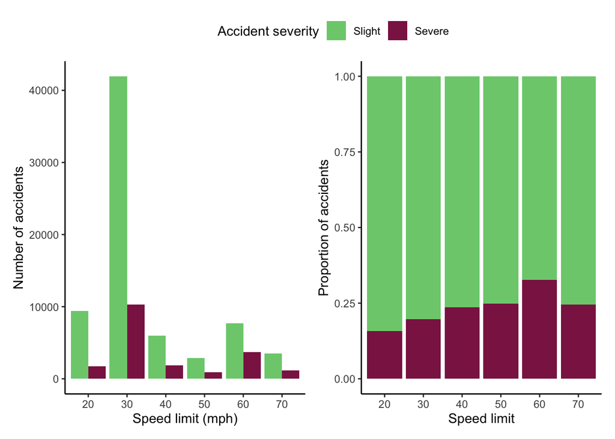

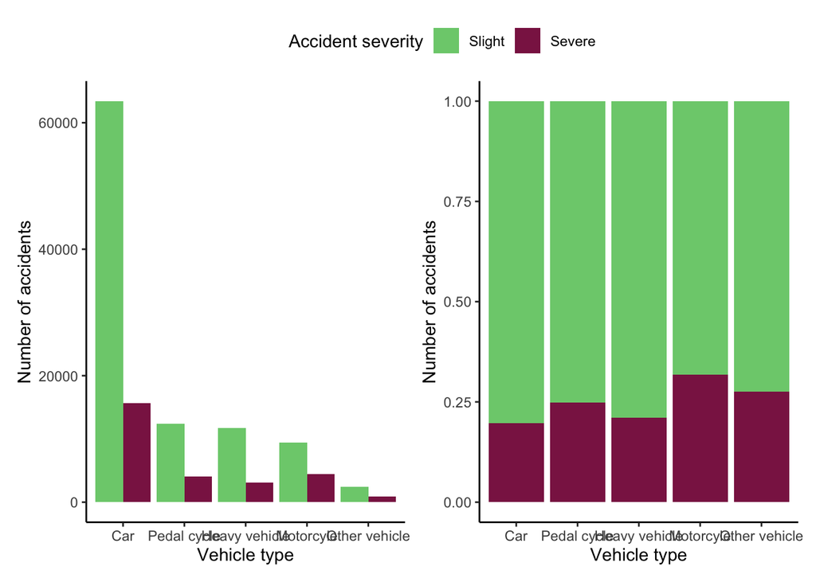

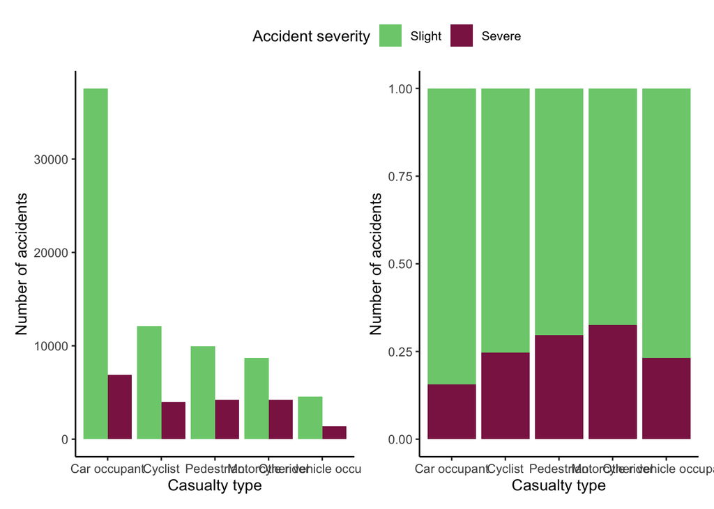

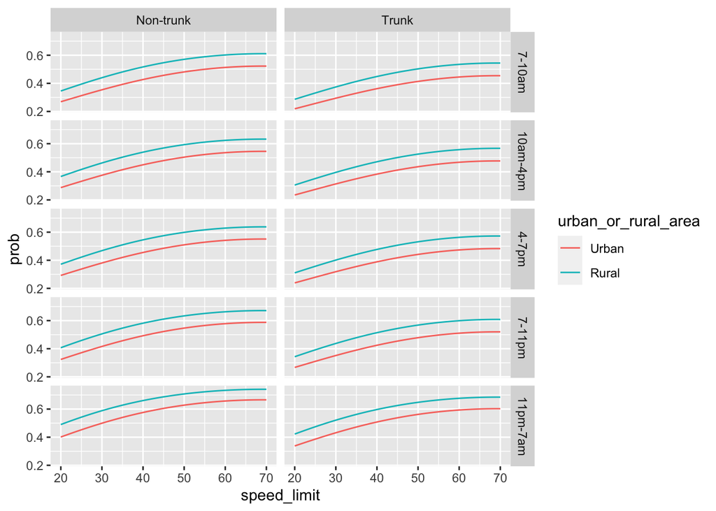

## Conclusions and discussion

We found that there were over 90,000 accidents reported in 2020, of which around fifth were classified as severe accidents. This high figure illustrates the potentially avoidable burden of death and injury caused by accidents on British roads.

This analysis has demonstrated that speed limit had an important role in the severity of accidents. The probability of a severe accident increased steadily from 16% (15-17%) at roads with 20mph to 31%(29-33%) at 60mph, falling slightly to 24% (22-26%) for roads with 70 mph limit. The reduction in probability of fatal or severe accidents roads with 60 miles per hour speed limit to 70 miles per hour speed limit could be explained by the fact that the 70 miles per hour speed limit is only in place on motorways and dual-carriageways, which may have fewer pedestrians or cyclists compared to other road types, thus reducing the severity of accidents.

Whilst the risk of severe accidents is higher with increased speed, it is important to note that roads with 30 miles per hour had the highest number of recorded accidents.

The risk of severe accidents was higher in rural areas (27%, 95% CI: 25-29%) compared to urban areas (19%, 95% CI:18-20%). Whilst we did not study the reasons for this difference, possible explanations include drivers driving at increased speed, reduced police presence, or the poorer quality of roads in more rural areas.

This study did not find evidence that the probability of an accident being severe differs for road surface conditions. The probability of an accident being severe in dry conditions was 22% (20-23%), 21% (20-23%) for wet/damp. The risk is similar, 21% (18-24%), for “other” road surface conditions, which included conditions of ice and snow amongst others. This unexpected finding may be explained by drivers exercising increased caution during conditions of ice or snow.

According to the model, the age of the car involved has a significant effect on whether the accident is classed as severe or not. Furthermore, older cars have greater odds of being involved in a severe accident. In fact, for every year older a car gets, the odds of a severe accident increase by 1%. Perhaps this is due to older cars having less safety features. Modern cars are much safer due to having improved crumple zones, improved airbags and electronic safety systems (the car investor.com)

The limitations of this study must be noted. First, important factors such as speeding, drunk driving and other driving and pedestrian behaviour related issues were not assessed as data were not available. Therefore, the various factors assessed in this study provide a partial explanation of the reasons for accidents. Nevertheless, this comprehensive analysis of all accidents in Great Britain has produced important findings.

## Technical Appendix

After creating a single dataset that combined all three datasets, the variables speed limit and maximum age of the vehicle were continuous variables and all other variables were converted to factor variables. As part of exploratory data analysis, the numbers of accidents across various categories and proportions of missing data were assessed. The number of accidents, casualty type and vehicle type were plotted against the outcome variable. We also reviewed contingency tables for each variable against the outcome to ensure that there were adequate numbers of observations in each cell for fitting a logistic regression model.

A multivariable logistic regression model was built with all explanatory variables described in the methods. We tested for non-linearity of continuous variables (speed limit and maximum age of vehicle) against the outcome. For speed limit, including a quadratic term improved model fit (as assessed by Likelihood Ratio test p-value <0.001). Adding a cubic term for speed limit did not improve model fit (LRT p-value>0.05). For maximum age of vehicle, adding a quadratic term did not improve model fit (LRT p-value >0.05). Goodness of fit was assessed and calculated pseudo R-squared value. In addition, we tested for significance of individual factors in improving model fit using Likelihood Ratio Test by comparing with and without each variable that was assessed. Although two variables had LRT p-value >0.05, we decided to retain all explanatory variables in the final model. The final model contained all factor variables, linear and quadratic functions of speed limit and linear function of maximum age of vehicle as continuous variables. The final model was based on 65, 624 complete observations. Finally, we calculated the predicted probabilities (with 95% confidence intervals) of outcome for the dataset based on the final model and plotted these for key factors of interest. All analysis were conducted in R (R Foundation for Statistical Computing, Vienna, Austria). For the primary analysis, we used tidyverse, janitor, finalfit and patchwork packages.

For the shiny app, we specified a baseline model with reference group values for all factor variables and five years for maximum age of the vehicle. The baseline model could be shown on the probability plot based on user preference. The probability plot is updated based on the parameter options chosen by the user.

## To do

- Check and verify supplied scripts
- Probit vs logit, etc
- LRT for model comparion, are we following Kostas method to arrive at the conclusion
- “adjusting for all other relevant factors” (remove all)
- We should explicitally handle NaNs
- Is there a definition for ‘fatal or serious’ and ‘slight’